# Assignment 2

## Centering our Covariate

We can improve the interpretation of the coefficients in our linear model by scaling and centering our covariates. With our mean centered on 0, this standardises the variable and eliminates the need to multiply the linear model coefficient for the covariant by the covariate’s mean.

By using the `scale()` function, we can create a scaled and centered version of our covariate in our data frame.

```r
q2_scaled_data <- q2_data_tidied %>%
  mutate(centred_caffeine = scale(caffeine))
```

We can compare the uncentered to the centered covariate using the `plot()` function to see that the data is unchanged, other than the variable mean now being centered on zero and the distribution being scaled.

**Uncentered covariate**

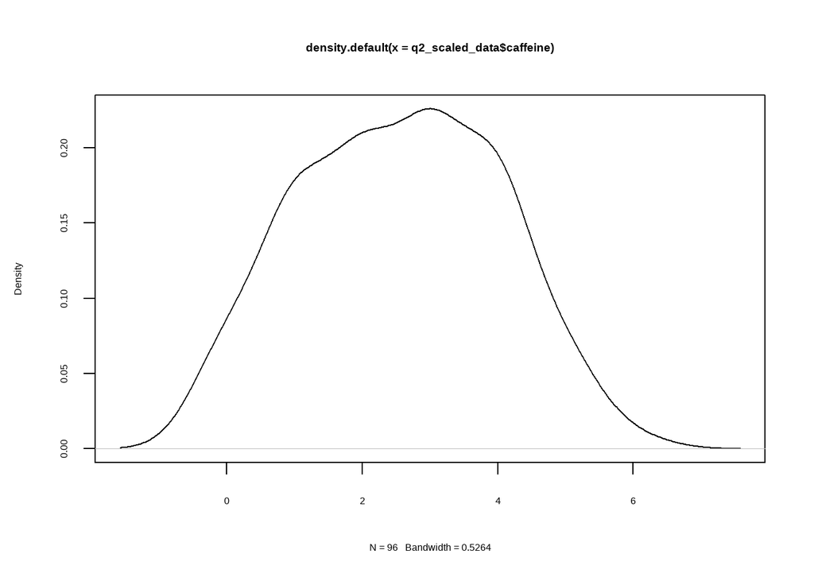

```r
plot(density(q2_scaled_data$caffeine))
```

**Centered covariate**

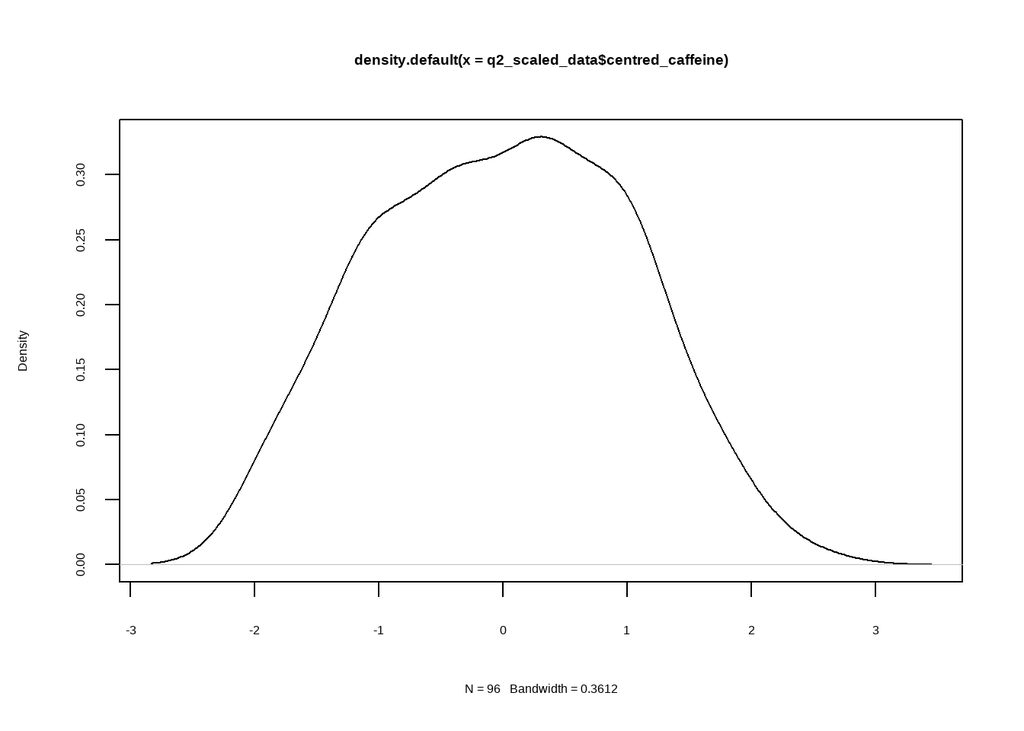

```r
plot(density(q2_scaled_data$centred_caffeine))
```

Finally, let’s build our linear model with the scaled and centered covariate.

```r
q2_ancova_centred <- lm(response_time ~ centred_caffeine + visual_quality, data = q2_scaled_data)
q2_ancova_centred
```

```
##
## Call:
## lm(formula = response_time ~ centred_caffeine + visual_quality,
##     data = q2_scaled_data)
##
## Coefficients:
##            (Intercept)        centred_caffeine  visual_qualityDegraded
##               1004.864                   3.598                  12.791
```

# Question 3

For our final question, let’s have a look at the experiment we’ve been given and read in our data:

> We have 148 participants in a 2 x 2 repeated measures design. We are interested in whether people respond differently to a target image following a prime image when we manipulate the image to be either positive or negative in valence. Two independent variables were manipulated within-participants in a fully factorial design; Prime Valence with two levels (Positive and Negative), and Target Valence with two levels (Positive and Negative). The time it took for participants to respond to the image, which was taken as a measure of reaction time in milliseconds, served as the dependent variable.

```r
raw_data_3 <- read_csv("assignment_2_dataset_3.csv")
head(raw_data_3)
```

```
## # A tibble: 6 x 5
##   participant positiveprime_positivetarget positiveprime_neg~ negativeprime_pos~
##         <dbl>                        <dbl>              <dbl>              <dbl>
## 1           1                        1502.              1657.              1535.
## 2           2                        1535.              1581.              1623.
## 3           3                        1563.              1495.              1545.
## 4           4                        1492.              1692.              1601.
## 5           5                        1560.              1584.              1497.
## 6           6                        1552.              1603.              1598.
## # ... with 1 more variable: negativeprime_negativetarget <dbl>
```

## Data Wrangling

Our data is currently in wider format, meaning that each row represents one participant. Instead, we want each row to represent one observation from each participant. To do this, we can lengthen the data using the `pivot_longer()` function.

```r
longer_data <- raw_data_3 %>%
  pivot_longer(cols = c(positiveprime_positivetarget, positiveprime_negativetarget,
                        negativeprime_positivetarget, negativeprime_negativetarget),
               names_to = "Condition",
               values_to = "reaction_time")
head(longer_data)
```

```
## # A tibble: 6 x 3
##   participant Condition                    reaction_time
##         <dbl> <chr>                                <dbl>
## 1           1 positiveprime_positivetarget         1502.
## 2           1 positiveprime_negativetarget         1657.
## 3           1 negativeprime_positivetarget         1535.
## 4           1 negativeprime_negativetarget         1596.
## 5           2 positiveprime_positivetarget         1535.
## 6           2 positiveprime_negativetarget         1581.
```

Our variables and conditions are still not labelled meaningfully - we can rename them using the `recode()` function. We also need to separate our ‘Condition’ variable and name them according to our independent variables so our tibble reflects the 2 x 2 structure of the experiment. The `separate()` function allows us to split ‘Prime Valence’ and ‘Target Valence’ into two different factors. Finally, we’ll recode our experimental variables as factors:

```r
q3_data_tidied <- longer_data %>%
  mutate(Condition = recode(Condition,
                            "positiveprime_positivetarget" = "Positive_Positive",
                            "positiveprime_negativetarget" = "Positive_Negative",
                            "negativeprime_positivetarget" = "Negative_Positive",
                            "negativeprime_negativetarget" = "Negative_Negative")) %>%
  separate(col = "Condition", into = c("prime_valence", "target_valence"), sep = "_") %>%
  mutate(prime_valence = factor(prime_valence), target_valence = factor(target_valence))
head(q3_data_tidied)
```

```
## # A tibble: 6 x 4
##   participant prime_valence target_valence reaction_time
##         <dbl> <fct>         <fct>                  <dbl>
## 1           1 Positive      Positive               1502.
## 2           1 Positive      Negative               1657.
## 3           1 Negative      Positive               1535.
## 4           1 Negative      Negative               1596.
## 5           2 Positive      Positive               1535.
## 6           2 Positive      Negative               1581.
```

## Data Summarising

Let’s generate some summary statistics and arrange the data from the fastest mean Reaction Time to the slowest. We need to specify our two grouping variables in the `group()` function call. I’ve mapped the output to a variable I’ve called `descriptive_stats` for later use in my visualisation.

```r
descriptive_stats <- q3_data_tidied %>%
  group_by(prime_valence, target_valence) %>%
  summarise(mean_RT = mean(reaction_time), sd_RT = sd(reaction_time)) %>%
  arrange(mean_RT)
head(descriptive_stats)
```

```
## # A tibble: 4 x 4
## # Groups:   prime_valence [2]
##   prime_valence target_valence mean_RT sd_RT
##   <fct>         <fct>            <dbl> <dbl>
## 1 Negative      Negative         1547.  52.4
## 2 Positive      Positive         1547.  44.9
## 3 Negative      Positive         1563.  50.5
## 4 Positive      Negative         1567.  54.0
```

Looking at the tibble, it seems like participants were quickest at identifying the image when the prime valence was congruent with the target valence. As before, our output has not returned any NA results, so no need to run the `vis_miss()` function. Let’s generate some data visualisations next.

## Data Visualisations

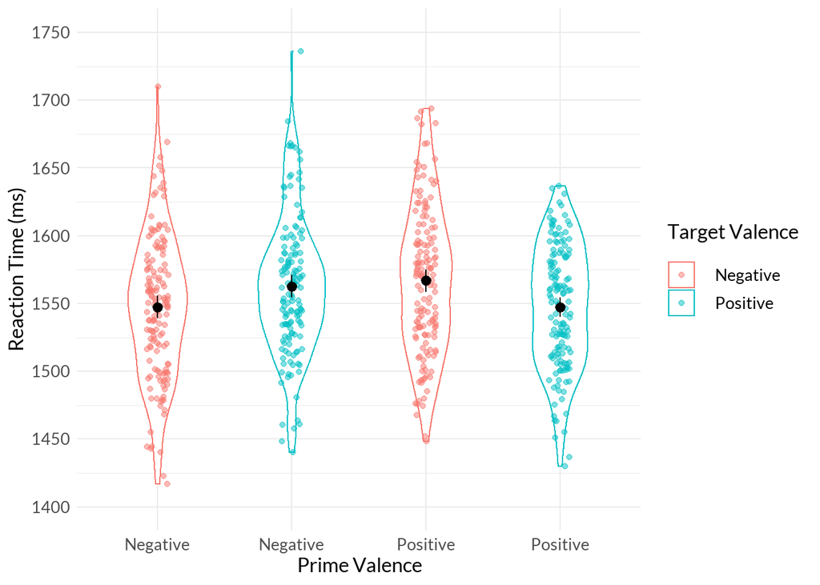

```r
q3_data_tidied %>%
  ggplot(aes(x = prime_valence:target_valence, y = reaction_time, colour = target_valence)) +
  geom_violin(width = .5) +
  geom_point(alpha = 0.5, position = position_jitter(width = 0.08, seed = 42)) +
  theme_minimal() +
  labs(x = "Prime Valence",
       y = "Reaction Time (ms)",
       colour = "Target Valence") +
  stat_summary(fun.data = "mean_cl_boot", colour = "black") +
  theme(text = element_text(size = 13)) +
  scale_y_continuous(breaks = seq(1400, 1750, by = 50),
                     limits = c(1400, 1750)) +
  scale_x_discrete(labels = c("Negative:Negative" = "Negative",
                              "Negative:Positive" = "Negative",
                              "Positive:Negative" = "Positive",
                              "Positive:Positive" = "Positive")) +
  theme(text = element_text(family = "lato", size = 25))
```

In this visualisation, I have plotted our ‘Prime’ condition along the x-axis and labelled them accordingly using the `scale_x_discrete()` function. I have also used the legend and an appropriate colour scheme to indicate which data represent our ‘Target Valence’ condition. However, it is difficult to see any interactions in this visualisation - we’ll need an interaction plot for this.

First, we’ll bring the legend closer to the lines by writing the labels of the lines directly behind the lines. To do this, we’ll create a new dataset that includes the y-values of the points where both lines end. We also need the labels that will be at the end of the lines. For this we use the function `case_when()`.

```r
labels <- descriptive_stats %>%
  filter(prime_valence == "Positive") %>%
  mutate(label = case_when(target_valence == "Negative" ~ "Negative Target Valence",
                           target_valence == "Positive" ~ "Positive Target Valence"))
head(labels)
```

```
## # A tibble: 2 x 5
## # Groups:   prime_valence [1]
##   prime_valence target_valence mean_RT sd_RT label
##   <fct>         <fct>            <dbl> <dbl> <chr>
## 1 Positive      Positive         1547.  44.9 Positive Target Valence
## 2 Positive      Negative         1567.  54.0 Negative Target Valence
```

Using the `descriptive_stats` dataset we created earlier, we can add the geom_text to our interaction plot and pass our dataset `labels` to the geom. Among the aesthetics, `geom_text()` includes the aesthetic label, which stands for the text we will add to the visualization. We’ve also scaled down the y-axis using the `scale_y_continuous()` function to visually increase the distance between the means, aiding interpretation.

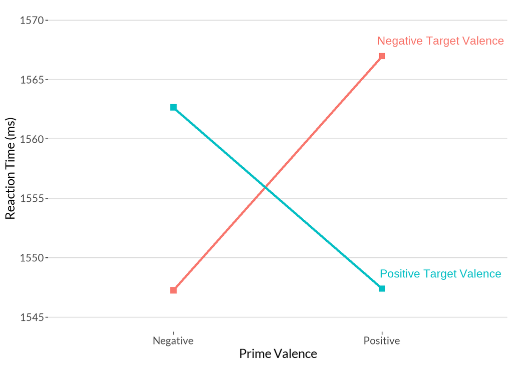

```r
descriptive_stats %>%
  ggplot(aes(x = prime_valence, y = mean_RT)) +
  geom_line(size = 1.2, aes(group = target_valence, colour = target_valence)) +
  geom_point(size = 2.6, aes(colour = target_valence), shape = 15) +
  geom_text(size = 8, aes(label = label,
                          colour = target_valence),
            data = labels,
            nudge_x = 0.28,
            nudge_y = 1.3) +
  guides(colour = 'none') +
  scale_y_continuous(breaks = seq(1545, 1570, by = 5),
                     limits = c(1545, 1570)) +
  labs(x = "Prime Valence",
       y = "Reaction Time (ms)") +
  theme_hc() +
  theme(text = element_text(family = "lato", size = 25))
```

We can see here that we have a crossover interaction as the polarity of the difference flips. The graph shows that Reaction Time was faster for positive prime images when the target image was also positive. Likewise, Reaction Time was faster for negative prime images when the target was also negative. Due to our crossover interaction, it is unlikely that we’ll have significant main effects of both Prime and Target factors, but a significant interaction effect is likely. Let’s build an ANOVA model to test these predictions.

## Building our ANOVA model

The syntax is very similar to what we ran previously, although this time we need to specify our two experimental factors using the term prime_valence * target_valence. This term corresponds to a main effect of prime valence, and a main effect of target valence, plus the interaction between the two factors. Our variables are both repeated measures factors, so we also have to specify them in our random effect term in the same way.

```r
factorial_anova <- aov_4(reaction_time ~ prime_valence * target_valence + (1 + target_valence * prime_valence | participant), data = q3_data_tidied)
anova(factorial_anova)
```

```
## Anova Table (Type 3 tests)
##
## Response: reaction_time
##                              num Df den Df    MSE       F       ges    Pr(>F)
## target_valence                    1    147 2730.5  0.2375 0.0004315    0.6267
## prime_valence                     1    147 2337.5  0.3157 0.0004908    0.5751
## target_valence:prime_valence      1    147 2626.3 17.2541 0.0292770 5.523e-05
##
## target_valence
## prime_valence
## target_valence:prime_valence ***
## ---
## Signif. codes:  0 '***' 0.001 '**' 0.01 '*' 0.05 '.' 0.1 ' ' 1
```

Just as we predicted from interpreting our interaction plot, we don’t have a significant main effect of Prime Valence or a significant main effect of Target Valence. However, we do have a significant interaction between our two experimental variables. Let’s conduct some pairwise comparisons to find out where the differences lie. We don’t need to change the error correction judgement as only some of the comparisons have any theoretical meaning.

```r
emmeans(factorial_anova, pairwise ~ prime_valence * target_valence, adjust = "none")
```

```
## $emmeans
##  prime_valence target_valence emmean    SE  df lower.CL upper.CL
##  Negative      Negative         1547 4.304 147     1539     1556
##  Positive      Negative         1567 4.439 147     1558     1576
##  Negative      Positive         1563 4.151 147     1554     1571
##  Positive      Positive         1547 3.689 147     1540     1555
##
## Confidence level used: 0.95
##
## $contrasts
##  contrast                              estimate   SE  df t.ratio p.value
##  Negative Negative - Positive Negative  -19.731 6.29 147  -3.138  0.0021
##  Negative Negative - Negative Positive  -15.405 5.98 147  -2.577  0.0110
##  Negative Negative - Positive Positive   -0.139 5.62 147  -0.025  0.9802
##  Positive Negative - Negative Positive    4.326 6.08 147   0.712  0.4776
##  Positive Negative - Positive Positive   19.591 6.05 147   3.236  0.0015
##  Negative Positive - Positive Positive   15.265 5.25 147   2.908  0.0042
```

In this output, we are interested in comparing Reaction Times to Negative Targets preceded by Negative vs. Positive Primes. We are also interested in comparing Reaction Times to Positive Targets preceded by Negative vs. Positive Primes. Therefore, the two key comparisons are:

- `Negative Negative - Positive Negative`
- `Negative Positive - Positive Positive`

Now that we know what our meaningful comparisons are, we can manually perform a Bonferroni correction test to correct for multiple comparisons. To do this, we multiple the corresponding *p*-values by 2 (which is the number of meaningful comparisons we have). We also need to put a maximum limit of 1 on our *p*-value, as *p* can never exceed 1.

**Negative Negative - Positive Negative corrected *p*-value**

```r
sum(0.0021*2)
```

```
## [1] 0.0042
```

**Negative Positive - Positive Positive corrected *p*-value**

```r
sum(0.0042*2)
```

```
## [1] 0.0084
```

For our first meaningful comparison, which is Reaction Time to Negative Targets when preceded by Negative vs. Positive Primes, we get a corrected *p*-value of .004. For our second meaningful comparison, which is Reaction Time to Positive Targets when preceded by Negative vs. Positive Primes, we get a corrected *p*-value of .008.

We conducted a 2 (Prime Valence: Positive vs. Negative) x 2 (Target Valence: Positive vs. Negative) repeated measures ANOVA to investigate the influence of Target Valence on reaction times when preceded by Positive or Negative Primes. The ANOVA revealed no effect of Prime Valence (*F* < 1), no effect of Target Valence (*F* < 1), but an interaction between Prime Valence and Target Valence (*F*(1, 147) = 17.25, *p* < .001, ηG2 = .029).